# The Simplest Introduction to Optimization EVER

J. Mao https://jiamingmao.github.io/principles-of-economics

Suppose we have a function:

$$y = 100 -20x + x^2$$
How do we find $x^*$ that minimizes $y$?

### 1. Define a Function

Firts, let us define the function $y(x)$ in `R`. Here’s how:

```r
y <- function(x) 100 - 20*x + x^2
```

That’s it! We have created the function $y(x)$. Let’s test it:

```r
y(5)
```

```
## [1] 25
```

Is this correct? Yes:

$$y(5) = 100 -20\times5 + 5^2=25$$

Now let’s plot this function:

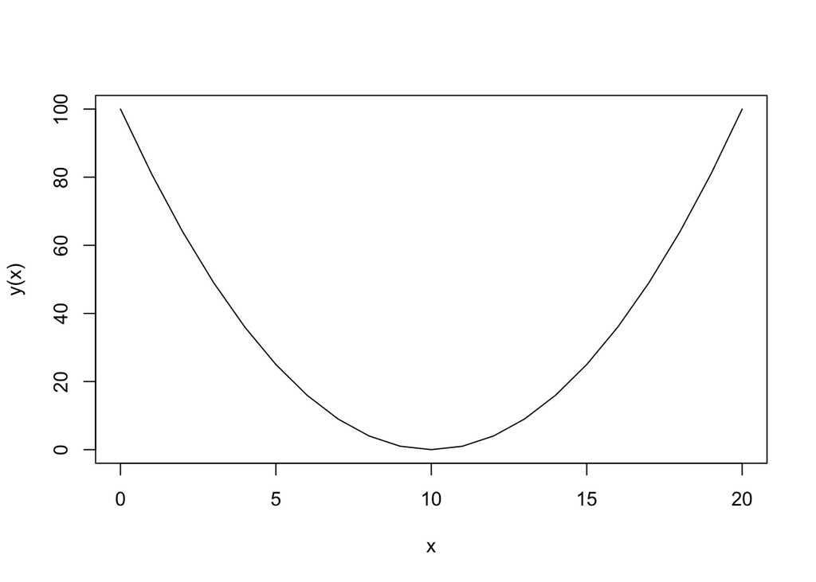

```r
x = 0:20
plot(x,y(x),type="l")
```

### 2. Finding the Minimum

Now let’s find the minimum point of $y(x)$. To do so, we use the function `optim`:

```r
x0 = 0 #the initial value of x that we want optim to start searching from.
result <- optim(x0, y) #Optim will start from x0 and then search through many values of x to find the xstar that minimizes y
xstar = result$par #the variable "result"" contains many values. "result$par" is what we want, which is the value of x that minimizes y(x). ("par" stands for "parameter")
xstar
```

```
## [1] 9.9
```

That’s it! We have found the $x^*$ that minimizes $y(x)$. This $x^*$ is a **numerical solution**, since we have found it by using computer programs to search for the best value. If we calculate by hand, we will get the theoretical solution, or **analytical solution**. Note that in this case, the numerical solution is $x^*=9.9$, which is close to the analytical solution, which is $x^*=10$.

### 3. Finding the Maximum

`optim` is for finding *minimum* values. How do we find the *maximum* value of a function?

Let’s define the following function:

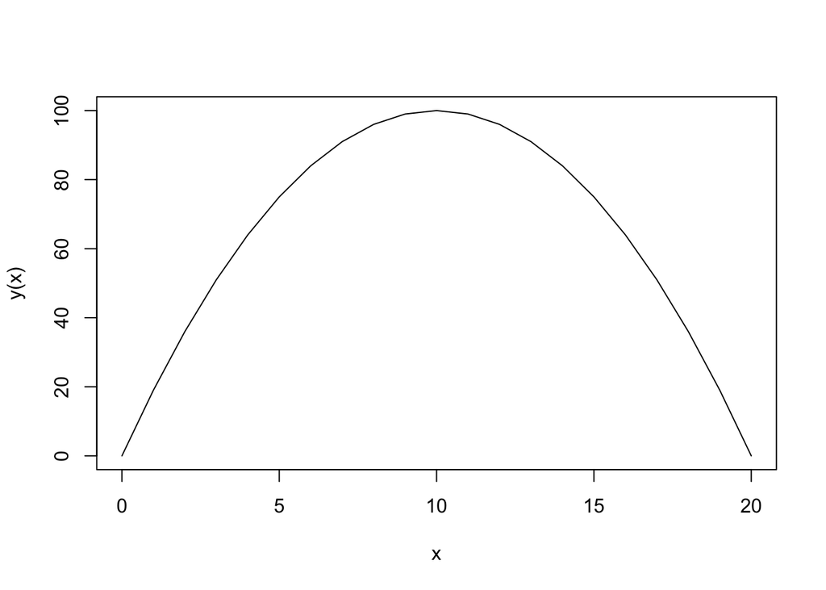

```r
y <- function(x) 20*x - x^2
x = 0:20
plot(x,y(x),type="l")
```

How do we find the maximum point of $y(x)$? Easy. We can still use `optim`, but let’s define another function $z(x)=-y(x)$:

```r
z <- function(x) -y(x)
```

Then we can just use the `optim` to find the *minimum* point of $z(x)$, which will be the same as finding the *maximum* point of $y(x)$:

```r
x0 = 0
result <- optim(x0, z)
xstar = result$par
xstar
```

```
## [1] 9.9
```

There we go! We have found the $x^*$ that maximizes $y(x)$!

### 4. Constrained Optimization

In many cases, function $y(x)$ is only defined on $x\in [a,b]$, i.e. $x$ has to be between $a$ and $b$. In this case, if we are searching for the $x^*$ that minimizes or maximizes $y(x)$, we will only search within the range $[a,b]$. This is called **constrained optimization**.

For example, let

$$y(p) = p(1-p)$$
, where $p\in [0,1]$

```r
y <- function(p) p*(1-p)
z <- function(p) -y(p) #minimize z = maximize y
result <- optim(0.5, z, lower=0, upper=1) #0.5 is initial value; lower and upper set lowerbound and upperbound
pstar = result$par
pstar
```

```
## [1] 0.5
```